# Barplot in R Markdown

Dr. Suborna Ahmed

# Preparing directory and data setup

In this lecture, we will be creating side-by-side graphs for two different species using the vri.csv file. For doing this use the `subset()` and `par()` functions such as were explained in previous lectures.

```r
# VRI data

vri_data<-read.csv("VRI_data.csv",header = T)

attach(vri_data)

# separating data by species
d1<- subset(vri_data, (SPECIES_CD_1 =='CW'))
d2<- subset(vri_data, (SPECIES_CD_1 =='PLC'))
```

# Add one legend for multiple graphs

We can add a legend for multiple graphs by using the `legend()` function. In this case, we have to use the last graph created as a reference to add the coordinates of the legend. Make sure that you give appropriate margin space in the graph for adding the legend using the `mai=` option in the `par()` function. Use `xpd=NA` to specify that we want the legend outside of the graph area.

```r
ylabel="Projected Height (m)"
xlabel="Projected Age (years)"
ylm=c(0,60)
xlm=c(0,470)

cxlb=1.1 # axis level - fontsize
cxaxis=1.1 # axis fontsize
maincx=2.5 # title font

row1=3 # age column number
row2=4 # ht column number
ldcex=1 # size ofpoints
ld=1
maxd1<- max(d2[,row2])
m1<-subset(d2, PROJ_HEIGHT_1==maxd1)
maxd2<- max(d1[,row2])
m2<-subset(d1, PROJ_HEIGHT_1==maxd2)
#names(vri_data)

# creating a permanent image file
png("One_legend.png", width=5, height=5, units = 'in', res=1200)
par(mfrow=c(1,2),mai=c(3,0.9,0.2,0.3), cex=1.0, xpd=NA) # mai is the margin

# graph 1
plot(d1[,row1],d1[,row2], type = "p", pch = 20, col = "blue",  ylim=ylm, xlim=xlm, cex=ldcex, cex.lab=cxlb, cex.axis=cxaxis,  xlab=xlabel, ylab=ylabel)
points(m2[,row1],m2[,row2], type = "p", pch =11, col = "red", lwd=ld)

# graph 2
plot(d2[,row1],d2[,row2], type = "p", pch = 20, col = "black",  ylim=ylm, xlim=xlm, cex=ldcex, cex.lab=cxlb, cex.axis=cxaxis,  xlab=xlabel, ylab=ylabel)
points(m1[,row1],m1[,row2], type = "p", pch =11, col = "red", lwd=ld)

legend(-700, -35, ncol=1 ,c("Projected height: Species is 'CW'", "Projected height: Species is 'PLC'", "Maximum Projected Height"), col = c("blue", "black", "red"), pch = c(20, 20, 11), cex=1, pt.cex=ld)

graphics.off()
```

# Creating barplots

For this section we will create a bar plot using the trees.txt file. Use the `read.table()` function for importing this file into R. Then:

1. Determine the type of variables that you have (categorical or numerical). In this case we want to know what type of variable is “CC”. Use the `class()` function for checking on this.
2. Use `table()` to create a vector with the counts of the number of items that you have in the CC column.
3. Use `barplot()` function to create a bar plot. Use the vector that you create with the counts as a file and modify graph limits, colours, and labels if desired.

```r
# .txt data file
trees <- read.table("trees.txt", header = TRUE)
# checking the data:
dim(trees)
```

```
## [1] 50  7
```

```r
names(trees)
```

```
## [1] "ID"      "Date"    "Species" "CC"      "NNT"     "DBH"     "Height"
```

```r
# attached all variables
attach(trees)

# crown class variable and create a table
class(CC)
```

```
## [1] "character"
```

```r
counts <- table(CC)
counts
```

```
## CC
##  C  D  I  S
## 14  9 19  8
```

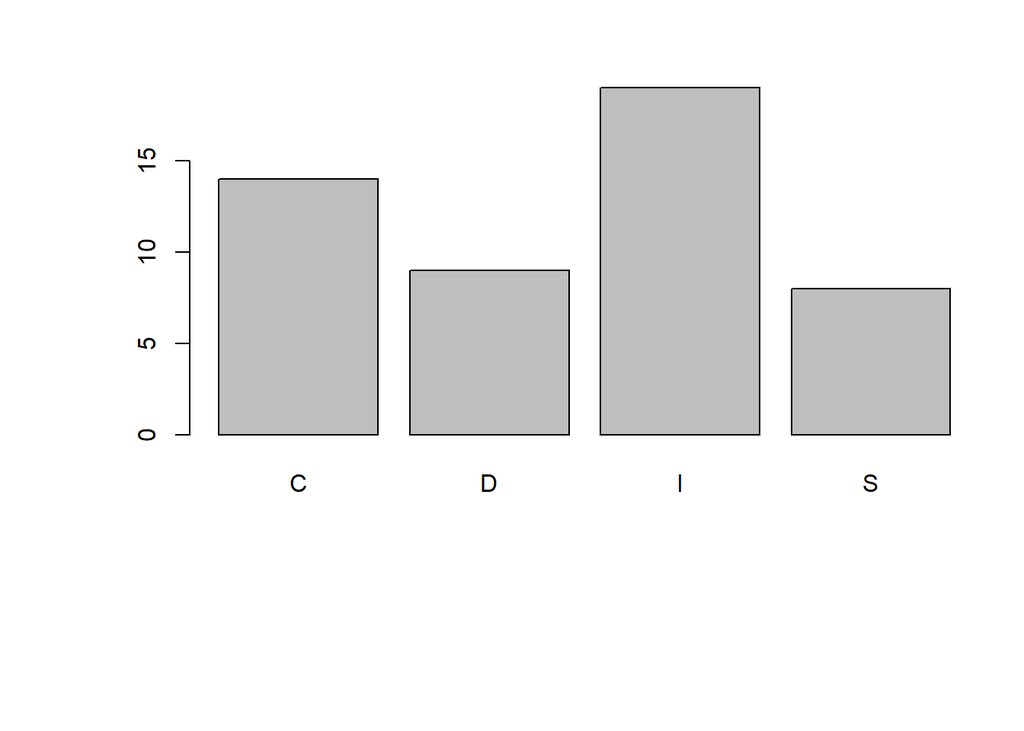

```r
#barplot 1
par(mfrow=c(1,1),mai=c(1,0.9,0.2,0.3), cex=1.0, oma=c(5,2,2,0), xpd=NA) # mai is the margin
barplot(counts)
```

```r
graphics.off()

#barplot 2
graphics.off()
par(mfrow=c(1,1),mai=c(1,0.9,0.2,0.3), cex=1.0, oma=c(5,2,2,0), xpd=NA) # mai is the margin
barplot(counts, ylim = c(0, 20))

#barplot 3
graphics.off()
par(mfrow=c(1,1),mai=c(1,0.9,0.2,0.3), cex=1.0, oma=c(5,2,2,0), xpd=NA) # mai is the margin
barplot(counts, ylim = c(0, 20), ylab = "Frequency", xlab = "Crown Classes")

detach(trees)
```

# VRI data bar chart

We can also create bar plots by selecting a categorical variable and using the `plot()` function. In this case, R will automatically create a bar plot with the selected categorical variable (e.g. `plot (SPECIES_CD_1)`). To change the direction of the numbers in the y axis use `las=1` into `barplot()`. To change the names in the x axis use `names.arg= c(“name_variable1”, “name_variable2”)`. This will change the names that you have for each column in the x axis. To modify the font size use `cex.names=`.

```r
attach(vri_data)
class(SPECIES_CD_1)
```

```
## [1] "character"
```

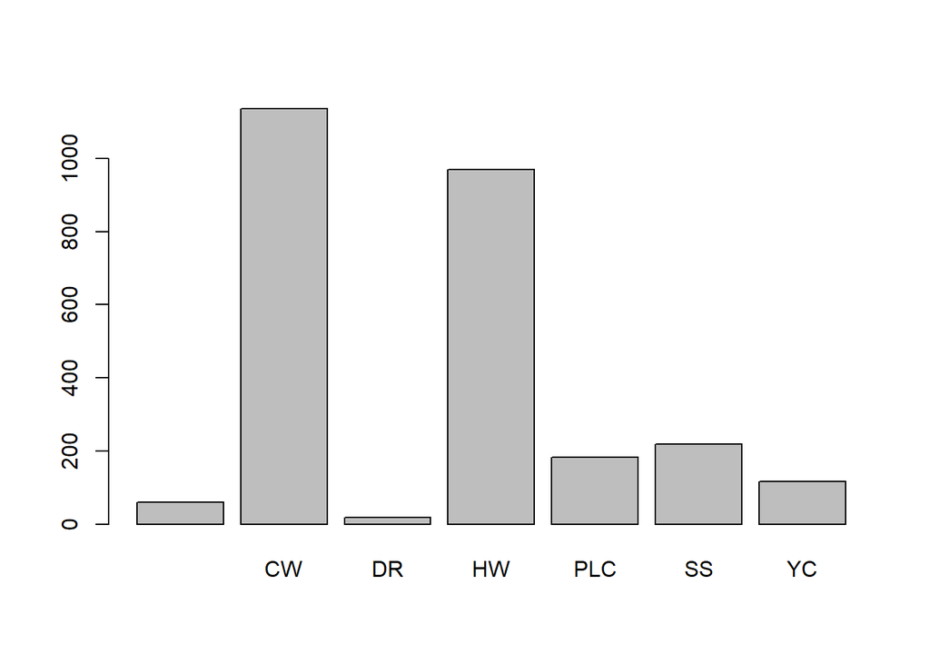

```r
#barplot 1
#coverting the character variable as a factor to plot it

plot(factor(SPECIES_CD_1))
```

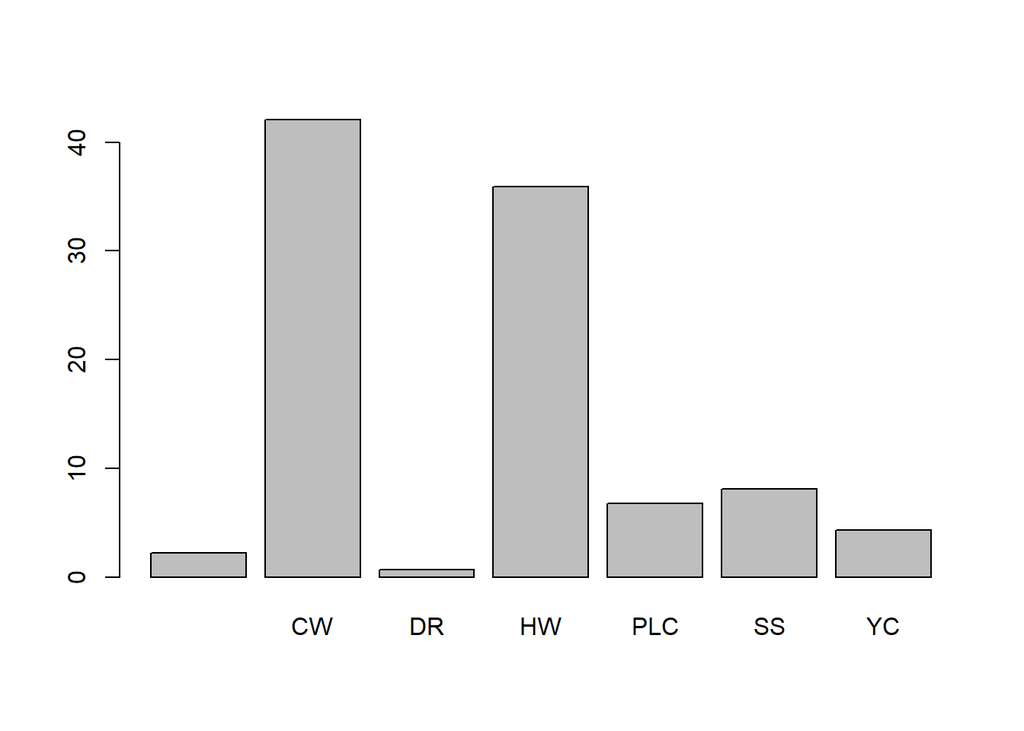

```r
#barplot 2
leading_spec <- table(SPECIES_CD_1)
percent_spec <- (table(SPECIES_CD_1)*100)/2700
barplot(percent_spec)
```

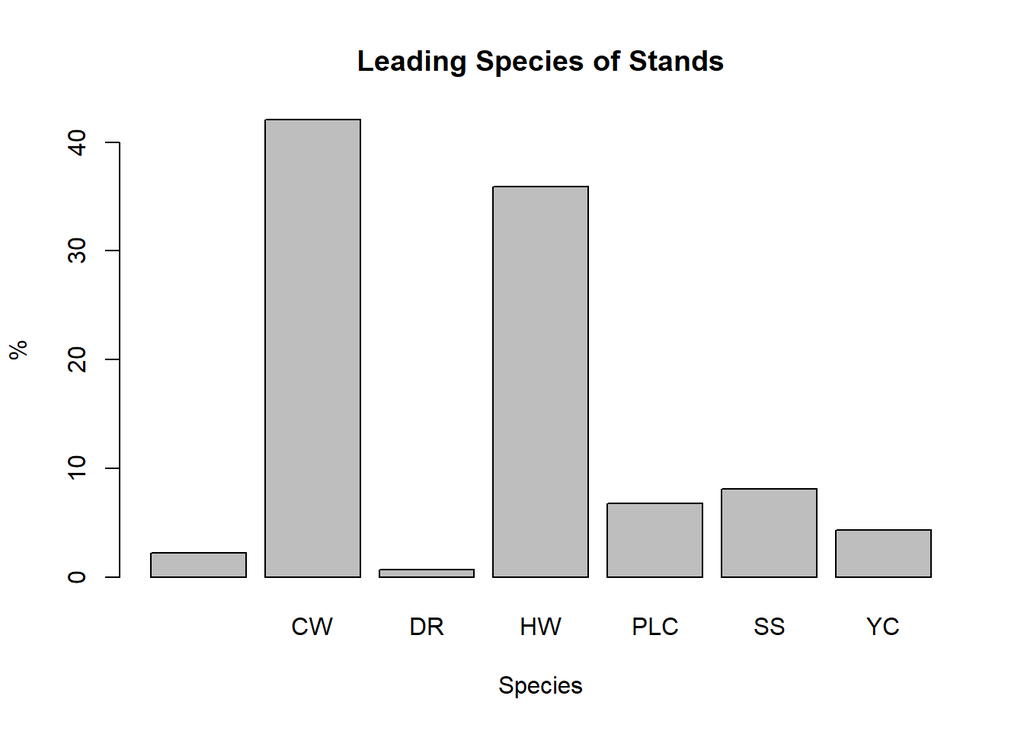

```r
#barplot 3
barplot(percent_spec, main="Leading Species of Stands",     xlab="Species", ylab="%")
```

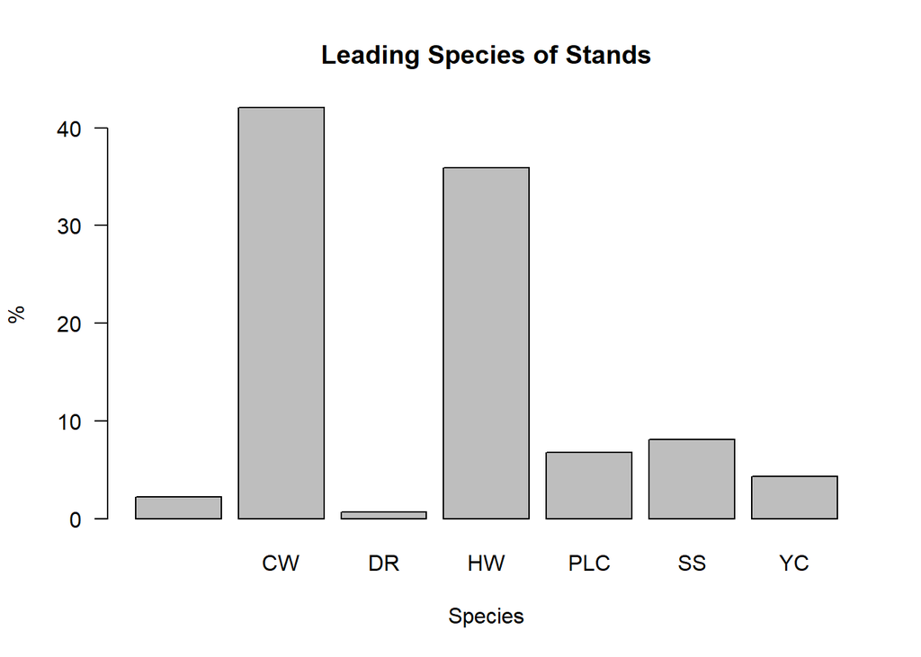

```r
#barplot 4: rotate y axis values:

barplot(percent_spec, main="Leading Species of Stands",     xlab="Species", ylab="%", las=1)
```

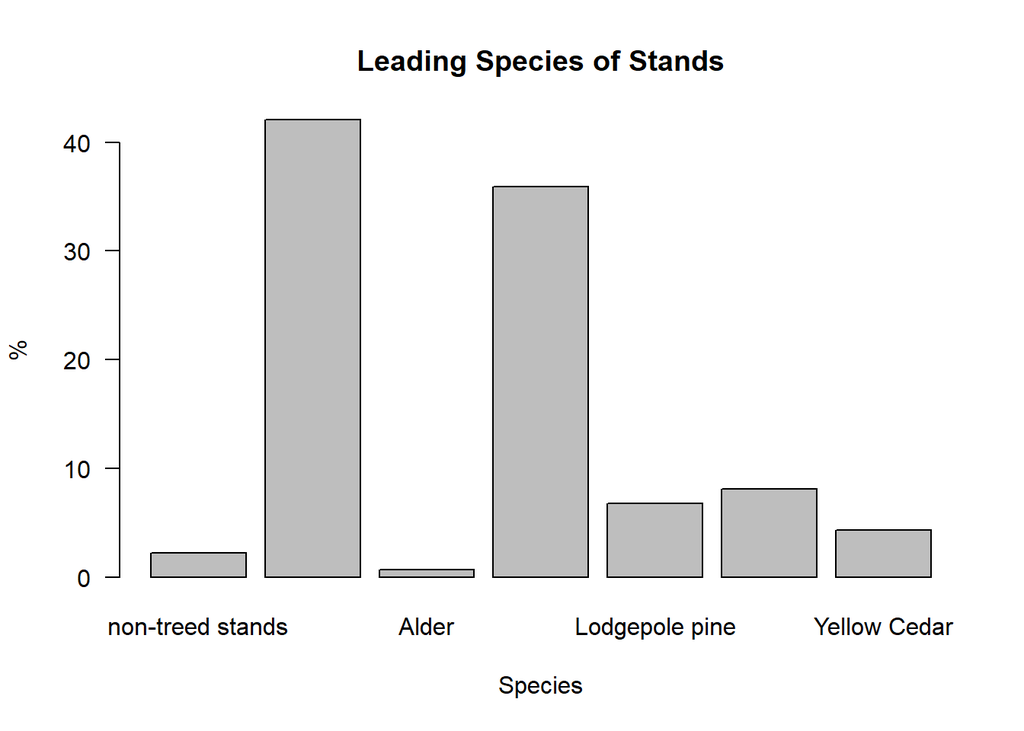

```r
#barplot 5
# set the names of categories under x axis:
barplot(percent_spec, main="Leading Species of Stands",     xlab="Species", ylab="%", las=1, names.arg=c("non-treed stands",  "Western Red Cedar",  "Alder", "Western Hemlock", "Lodgepole pine",  "Sitka Spruce", "Yellow  Cedar"))
```

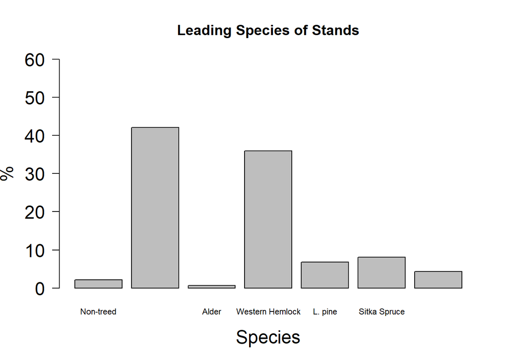

```r
# barplot 6: reduce the names to adjust the space
barplot(percent_spec, main="Leading Species of Stands",     xlab="Species", ylab="%", las=1, names.arg=c("Non-treed",  "Western R. Cedar",  "Alder", "Western Hemlock", "L. pine",  "Sitka Spruce", "Yellow     Cedar"), ylim=c(0,60), cex.axis=1.5, cex.lab=1.5, cex.names=0.7)
```